# CS 422

Julen Ferro Bañales. Master’s in CDS&OR, Illinois Institute of Technology

### Part 2.1.

1. Data cleanup (0.5 points)

Importing required modules.

```r
library(factoextra)
library(dplyr)
library(NbClust)
library(ggplot2)
library(ggpubr)
library(dbscan)
```

### Part 2.1-A-i

After having taken a look at the data set, it has been concluded that the numerical information will not the dropped. That is to say, the majority of the columns are filled with numerical information and would be used for the analysis, even though some of the columns’ data could not be correlated with the results that it is wanted, or some columns’ data could be a linear combination of others, as there will no be any statistical screening concerning the influence of each attribute, it cannot be concluded that deleting any of the numerical values will not lead to an information lose. About the first column, in which the names of the subject samples appers, this data is not really important for the data analysis, so it could be deleted.

```r
set.seed(123) # setting a seed for the pseudo-random numbers
rm(list=ls())
dataframe <- read.csv(file = "file19.txt",     # TXT data file indicated as string or full path to the file
           header = TRUE,    # Whether to display the header (TRUE) or not (FALSE)
           sep = "",          # Separator of the columns of the file
           dec = ".",
           skip = 20,
           strip.white = TRUE,
           skipNul = TRUE)         # Character used to separate decimals of the numbers in the file

head(df, 8) # df before getting rid of the names
```

[output not shown]

```r
df = dataframe[, 2:ncol(dataframe)] # getting rid of the names in the df
head(df, 8) # df after getting rid of the names
```

|  | I | i | C | c | P | p | M | m |
| --- | --- | --- | --- | --- | --- | --- | --- | --- |
| 1 | 5 | 4 | 1 | 1 | 3 | 3 | 4 | 4 |
| 2 | 3 | 3 | 1 | 1 | 4 | 4 | 3 | 3 |
| 3 | 3 | 2 | 1 | 0 | 3 | 3 | 3 | 3 |
| 4 | 3 | 3 | 1 | 1 | 4 | 4 | 3 | 3 |
| 5 | 2 | 3 | 1 | 1 | 3 | 3 | 3 | 3 |
| 6 | 2 | 3 | 1 | 1 | 2 | 3 | 3 | 3 |
| 7 | 2 | 3 | 1 | 1 | 2 | 2 | 3 | 3 |
| 8 | 2 | 3 | 1 | 1 | 1 | 2 | 3 | 3 |

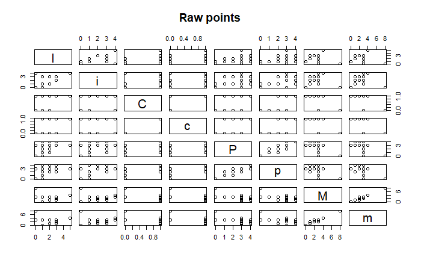

```r
plot(df, main="Raw points")
```

```r
df <- scale(df)
```